# Risk Factor Analysis

## Outcome Variable

**Outcome Variable:** sstunted

## Predictor Variables

**Intervention Variable:** impfloor

**Adjustment Set:**

- arm
- sex
- W_mage
- meducyrs
- feducyrs
- hhwealth_quart
- hfoodsec
- W_mhtcm
- W_nrooms
- W_nchldlt5
- W_parity
- impsan
- safeh20
- delta_W_mage
- delta_meducyrs
- delta_feducyrs
- delta_hhwealth_quart
- delta_hfoodsec
- delta_W_mhtcm
- delta_W_nrooms
- delta_W_nchldlt5
- delta_W_parity
- delta_impsan
- delta_safeh20

## Stratifying Variables

The analysis was stratified on these variable(s):

- agecat
- studyid
- country

## Data Summary

| agecat | studyid | country | impfloor | sstunted | n_cell | n |
| --- | --- | --- | --- | --- | --- | --- |
| Birth | ki0047075b-MAL-ED | BANGLADESH | 0 | 0 | 18 | 234 |
| Birth | ki0047075b-MAL-ED | BANGLADESH | 0 | 1 | 0 | 234 |
| Birth | ki0047075b-MAL-ED | BANGLADESH | 1 | 0 | 210 | 234 |
| Birth | ki0047075b-MAL-ED | BANGLADESH | 1 | 1 | 6 | 234 |
| Birth | ki0047075b-MAL-ED | BRAZIL | 0 | 0 | 2 | 174 |
| Birth | ki0047075b-MAL-ED | BRAZIL | 0 | 1 | 0 | 174 |
| Birth | ki0047075b-MAL-ED | BRAZIL | 1 | 0 | 165 | 174 |
| Birth | ki0047075b-MAL-ED | BRAZIL | 1 | 1 | 7 | 174 |
| Birth | ki0047075b-MAL-ED | INDIA | 0 | 0 | 10 | 191 |
| Birth | ki0047075b-MAL-ED | INDIA | 0 | 1 | 0 | 191 |
| Birth | ki0047075b-MAL-ED | INDIA | 1 | 0 | 174 | 191 |
| Birth | ki0047075b-MAL-ED | INDIA | 1 | 1 | 7 | 191 |
| Birth | ki0047075b-MAL-ED | NEPAL | 0 | 0 | 96 | 164 |
| Birth | ki0047075b-MAL-ED | NEPAL | 0 | 1 | 2 | 164 |
| Birth | ki0047075b-MAL-ED | NEPAL | 1 | 0 | 62 | 164 |
| Birth | ki0047075b-MAL-ED | NEPAL | 1 | 1 | 4 | 164 |
| Birth | ki0047075b-MAL-ED | PERU | 0 | 0 | 199 | 259 |
| Birth | ki0047075b-MAL-ED | PERU | 0 | 1 | 4 | 259 |
| Birth | ki0047075b-MAL-ED | PERU | 1 | 0 | 53 | 259 |
| Birth | ki0047075b-MAL-ED | PERU | 1 | 1 | 3 | 259 |
| Birth | ki0047075b-MAL-ED | SOUTH AFRICA | 0 | 0 | 21 | 218 |
| Birth | ki0047075b-MAL-ED | SOUTH AFRICA | 0 | 1 | 0 | 218 |
| Birth | ki0047075b-MAL-ED | SOUTH AFRICA | 1 | 0 | 196 | 218 |
| Birth | ki0047075b-MAL-ED | SOUTH AFRICA | 1 | 1 | 1 | 218 |
| Birth | ki0047075b-MAL-ED | TANZANIA, UNITED REPUBLIC OF | 0 | 0 | 105 | 117 |
| Birth | ki0047075b-MAL-ED | TANZANIA, UNITED REPUBLIC OF | 0 | 1 | 4 | 117 |
| Birth | ki0047075b-MAL-ED | TANZANIA, UNITED REPUBLIC OF | 1 | 0 | 7 | 117 |
| Birth | ki0047075b-MAL-ED | TANZANIA, UNITED REPUBLIC OF | 1 | 1 | 1 | 117 |
| Birth | ki1000108-CMC-V-BCS-2002 | INDIA | 0 | 0 | 0 | 71 |
| Birth | ki1000108-CMC-V-BCS-2002 | INDIA | 0 | 1 | 0 | 71 |

[output cut: 154 more lines]

The following strata were considered:

- agecat: 24 months, studyid: ki0047075b-MAL-ED, country: BANGLADESH
- agecat: 24 months, studyid: ki0047075b-MAL-ED, country: BRAZIL
- agecat: 24 months, studyid: ki0047075b-MAL-ED, country: INDIA
- agecat: 24 months, studyid: ki0047075b-MAL-ED, country: NEPAL
- agecat: 24 months, studyid: ki0047075b-MAL-ED, country: PERU
- agecat: 24 months, studyid: ki0047075b-MAL-ED, country: SOUTH AFRICA
- agecat: 24 months, studyid: ki0047075b-MAL-ED, country: TANZANIA, UNITED REPUBLIC OF
- agecat: 24 months, studyid: ki1000108-CMC-V-BCS-2002, country: INDIA
- agecat: 24 months, studyid: ki1000108-IRC, country: INDIA
- agecat: 24 months, studyid: ki1017093-NIH-Birth, country: BANGLADESH
- agecat: 24 months, studyid: ki1017093b-PROVIDE, country: BANGLADESH
- agecat: 24 months, studyid: ki1017093c-NIH-Crypto, country: BANGLADESH
- agecat: 24 months, studyid: ki1113344-GMS-Nepal, country: NEPAL
- agecat: 24 months, studyid: ki1114097-CONTENT, country: PERU
- agecat: 24 months, studyid: kiGH5241-JiVitA-3, country: BANGLADESH
- agecat: 24 months, studyid: kiGH5241-JiVitA-4, country: BANGLADESH
- agecat: 6 months, studyid: ki0047075b-MAL-ED, country: BANGLADESH
- agecat: 6 months, studyid: ki0047075b-MAL-ED, country: BRAZIL
- agecat: 6 months, studyid: ki0047075b-MAL-ED, country: INDIA
- agecat: 6 months, studyid: ki0047075b-MAL-ED, country: NEPAL
- agecat: 6 months, studyid: ki0047075b-MAL-ED, country: PERU
- agecat: 6 months, studyid: ki0047075b-MAL-ED, country: SOUTH AFRICA
- agecat: 6 months, studyid: ki0047075b-MAL-ED, country: TANZANIA, UNITED REPUBLIC OF
- agecat: 6 months, studyid: ki1000108-CMC-V-BCS-2002, country: INDIA
- agecat: 6 months, studyid: ki1000108-IRC, country: INDIA
- agecat: 6 months, studyid: ki1017093-NIH-Birth, country: BANGLADESH
- agecat: 6 months, studyid: ki1017093b-PROVIDE, country: BANGLADESH
- agecat: 6 months, studyid: ki1017093c-NIH-Crypto, country: BANGLADESH
- agecat: 6 months, studyid: ki1113344-GMS-Nepal, country: NEPAL
- agecat: 6 months, studyid: ki1114097-CONTENT, country: PERU
- agecat: 6 months, studyid: kiGH5241-JiVitA-3, country: BANGLADESH
- agecat: 6 months, studyid: kiGH5241-JiVitA-4, country: BANGLADESH
- agecat: Birth, studyid: ki0047075b-MAL-ED, country: BANGLADESH
- agecat: Birth, studyid: ki0047075b-MAL-ED, country: BRAZIL
- agecat: Birth, studyid: ki0047075b-MAL-ED, country: INDIA
- agecat: Birth, studyid: ki0047075b-MAL-ED, country: NEPAL
- agecat: Birth, studyid: ki0047075b-MAL-ED, country: PERU
- agecat: Birth, studyid: ki0047075b-MAL-ED, country: SOUTH AFRICA
- agecat: Birth, studyid: ki0047075b-MAL-ED, country: TANZANIA, UNITED REPUBLIC OF
- agecat: Birth, studyid: ki1000108-CMC-V-BCS-2002, country: INDIA
- agecat: Birth, studyid: ki1000108-IRC, country: INDIA
- agecat: Birth, studyid: ki1017093-NIH-Birth, country: BANGLADESH
- agecat: Birth, studyid: ki1017093c-NIH-Crypto, country: BANGLADESH
- agecat: Birth, studyid: ki1114097-CONTENT, country: PERU
- agecat: Birth, studyid: kiGH5241-JiVitA-3, country: BANGLADESH
- agecat: Birth, studyid: kiGH5241-JiVitA-4, country: BANGLADESH

### Dropped Strata

Some strata were dropped due to rare outcomes:

- agecat: Birth, studyid: ki0047075b-MAL-ED, country: BANGLADESH
- agecat: Birth, studyid: ki0047075b-MAL-ED, country: BRAZIL
- agecat: Birth, studyid: ki0047075b-MAL-ED, country: INDIA
- agecat: Birth, studyid: ki0047075b-MAL-ED, country: NEPAL
- agecat: Birth, studyid: ki0047075b-MAL-ED, country: PERU
- agecat: Birth, studyid: ki0047075b-MAL-ED, country: SOUTH AFRICA
- agecat: Birth, studyid: ki0047075b-MAL-ED, country: TANZANIA, UNITED REPUBLIC OF
- agecat: Birth, studyid: ki1000108-CMC-V-BCS-2002, country: INDIA
- agecat: Birth, studyid: ki1000108-IRC, country: INDIA
- agecat: Birth, studyid: ki1017093-NIH-Birth, country: BANGLADESH
- agecat: Birth, studyid: ki1017093c-NIH-Crypto, country: BANGLADESH
- agecat: Birth, studyid: ki1114097-CONTENT, country: PERU
- agecat: 6 months, studyid: ki0047075b-MAL-ED, country: BANGLADESH
- agecat: 6 months, studyid: ki0047075b-MAL-ED, country: BRAZIL
- agecat: 6 months, studyid: ki0047075b-MAL-ED, country: INDIA
- agecat: 6 months, studyid: ki0047075b-MAL-ED, country: NEPAL
- agecat: 6 months, studyid: ki0047075b-MAL-ED, country: PERU
- agecat: 6 months, studyid: ki0047075b-MAL-ED, country: SOUTH AFRICA
- agecat: 6 months, studyid: ki0047075b-MAL-ED, country: TANZANIA, UNITED REPUBLIC OF
- agecat: 6 months, studyid: ki1000108-CMC-V-BCS-2002, country: INDIA
- agecat: 6 months, studyid: ki1000108-IRC, country: INDIA
- agecat: 6 months, studyid: ki1017093-NIH-Birth, country: BANGLADESH
- agecat: 6 months, studyid: ki1113344-GMS-Nepal, country: NEPAL
- agecat: 6 months, studyid: ki1114097-CONTENT, country: PERU
- agecat: 24 months, studyid: ki0047075b-MAL-ED, country: BANGLADESH
- agecat: 24 months, studyid: ki0047075b-MAL-ED, country: BRAZIL
- agecat: 24 months, studyid: ki0047075b-MAL-ED, country: INDIA
- agecat: 24 months, studyid: ki0047075b-MAL-ED, country: NEPAL
- agecat: 24 months, studyid: ki0047075b-MAL-ED, country: PERU
- agecat: 24 months, studyid: ki0047075b-MAL-ED, country: SOUTH AFRICA
- agecat: 24 months, studyid: ki0047075b-MAL-ED, country: TANZANIA, UNITED REPUBLIC OF
- agecat: 24 months, studyid: ki1000108-CMC-V-BCS-2002, country: INDIA
- agecat: 24 months, studyid: ki1000108-IRC, country: INDIA
- agecat: 24 months, studyid: ki1114097-CONTENT, country: PERU

## Methods Detail

We’re interested in the causal parameters $E[Y_a]$ for all values of $a \in \mathcal{A}$. These parameters represent the mean outcome if, possibly contrary to fact, we intervened to set all units to have $A=a$. Under the randomization and positivity assumptions, these are identified by the statistical parameters $\psi_a=E_W[E_{Y|A,W}(Y|A=a,W)]$. In addition, we’re interested in the mean of $Y$, $E[Y]$ under no intervention (the observed mean). We will estimate these parameters by using SuperLearner to fit the relevant likelihood factors – $E_{Y|A,W}(Y|A=a,W)$ and $p(A=a|W)$, and then updating our likelihood fit using a joint TMLE.

For unadjusted analyses ($W=\{\}$), initial likelihoods were estimated using Lrnr_glm to estimate the simple $E(Y|A)$ and Lrnr_mean to estimate $p(A)$. For adjusted analyses, a small library containing Lrnr_glmnet, Lrnr_xgboost, and Lrnr_mean was used.

Having estimated these parameters, we will then use the delta method to estimate relative risks and attributable risks relative to a prespecified baseline level of $A$.

# Results Detail

## Results Plots

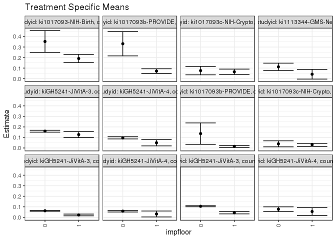

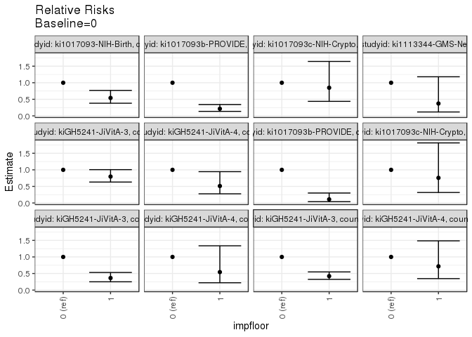

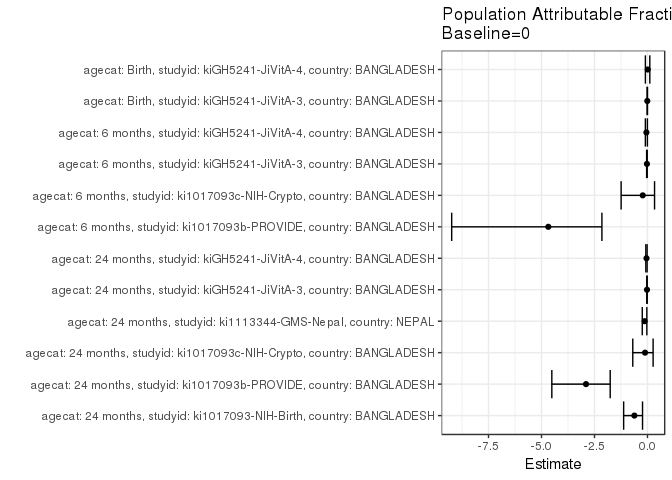

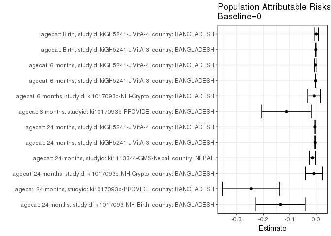

## Results Table

### Parameter: TSM

| agecat | studyid | country | intervention_level | baseline_level | estimate | ci_lower | ci_upper |
| --- | --- | --- | --- | --- | --- | --- | --- |
| Birth | kiGH5241-JiVitA-3 | BANGLADESH | 0 | NA | 0.1049872 | 0.1001937 | 0.1097807 |
| Birth | kiGH5241-JiVitA-3 | BANGLADESH | 1 | NA | 0.0441425 | 0.0326782 | 0.0556068 |
| Birth | kiGH5241-JiVitA-4 | BANGLADESH | 0 | NA | 0.0769721 | 0.0542217 | 0.0997225 |
| Birth | kiGH5241-JiVitA-4 | BANGLADESH | 1 | NA | 0.0551574 | 0.0183154 | 0.0919994 |
| 6 months | ki1017093b-PROVIDE | BANGLADESH | 0 | NA | 0.1363636 | 0.0348769 | 0.2378504 |
| 6 months | ki1017093b-PROVIDE | BANGLADESH | 1 | NA | 0.0148423 | 0.0046251 | 0.0250595 |
| 6 months | ki1017093c-NIH-Crypto | BANGLADESH | 0 | NA | 0.0393258 | 0.0107520 | 0.0678997 |
| 6 months | ki1017093c-NIH-Crypto | BANGLADESH | 1 | NA | 0.0297952 | 0.0154049 | 0.0441854 |
| 6 months | kiGH5241-JiVitA-3 | BANGLADESH | 0 | NA | 0.0621237 | 0.0581449 | 0.0661024 |
| 6 months | kiGH5241-JiVitA-3 | BANGLADESH | 1 | NA | 0.0225820 | 0.0141599 | 0.0310040 |
| 6 months | kiGH5241-JiVitA-4 | BANGLADESH | 0 | NA | 0.0585315 | 0.0505773 | 0.0664857 |
| 6 months | kiGH5241-JiVitA-4 | BANGLADESH | 1 | NA | 0.0317521 | 0.0036076 | 0.0598965 |
| 24 months | ki1017093-NIH-Birth | BANGLADESH | 0 | NA | 0.3525376 | 0.2488535 | 0.4562216 |
| 24 months | ki1017093-NIH-Birth | BANGLADESH | 1 | NA | 0.1908684 | 0.1516398 | 0.2300969 |
| 24 months | ki1017093b-PROVIDE | BANGLADESH | 0 | NA | 0.3311889 | 0.2158184 | 0.4465594 |
| 24 months | ki1017093b-PROVIDE | BANGLADESH | 1 | NA | 0.0713776 | 0.0495052 | 0.0932499 |
| 24 months | ki1017093c-NIH-Crypto | BANGLADESH | 0 | NA | 0.0759171 | 0.0360730 | 0.1157612 |
| 24 months | ki1017093c-NIH-Crypto | BANGLADESH | 1 | NA | 0.0644394 | 0.0385447 | 0.0903341 |
| 24 months | ki1113344-GMS-Nepal | NEPAL | 0 | NA | 0.1118211 | 0.0768626 | 0.1467796 |
| 24 months | ki1113344-GMS-Nepal | NEPAL | 1 | NA | 0.0416667 | -0.0045501 | 0.0878834 |
| 24 months | kiGH5241-JiVitA-3 | BANGLADESH | 0 | NA | 0.1592779 | 0.1503098 | 0.1682461 |
| 24 months | kiGH5241-JiVitA-3 | BANGLADESH | 1 | NA | 0.1268913 | 0.0981445 | 0.1556381 |
| 24 months | kiGH5241-JiVitA-4 | BANGLADESH | 0 | NA | 0.0963636 | 0.0860398 | 0.1066873 |
| 24 months | kiGH5241-JiVitA-4 | BANGLADESH | 1 | NA | 0.0493167 | 0.0197777 | 0.0788557 |

### Parameter: E(Y)

| agecat | studyid | country | intervention_level | baseline_level | estimate | ci_lower | ci_upper |
| --- | --- | --- | --- | --- | --- | --- | --- |
| Birth | kiGH5241-JiVitA-3 | BANGLADESH | NA | NA | 0.1041251 | 0.0994430 | 0.1088072 |
| Birth | kiGH5241-JiVitA-4 | BANGLADESH | NA | NA | 0.0778589 | 0.0559066 | 0.0998111 |
| 6 months | ki1017093b-PROVIDE | BANGLADESH | NA | NA | 0.0240137 | 0.0115761 | 0.0364514 |
| 6 months | ki1017093c-NIH-Crypto | BANGLADESH | NA | NA | 0.0321678 | 0.0192256 | 0.0451101 |
| 6 months | kiGH5241-JiVitA-3 | BANGLADESH | NA | NA | 0.0605654 | 0.0567056 | 0.0644251 |
| 6 months | kiGH5241-JiVitA-4 | BANGLADESH | NA | NA | 0.0557203 | 0.0488106 | 0.0626301 |
| 24 months | ki1017093-NIH-Birth | BANGLADESH | NA | NA | 0.2177986 | 0.1786036 | 0.2569935 |
| 24 months | ki1017093b-PROVIDE | BANGLADESH | NA | NA | 0.0849220 | 0.0621566 | 0.1076874 |
| 24 months | ki1017093c-NIH-Crypto | BANGLADESH | NA | NA | 0.0680934 | 0.0462948 | 0.0898920 |
| 24 months | ki1113344-GMS-Nepal | NEPAL | NA | NA | 0.0987013 | 0.0688696 | 0.1285330 |
| 24 months | kiGH5241-JiVitA-3 | BANGLADESH | NA | NA | 0.1557625 | 0.1470150 | 0.1645100 |
| 24 months | kiGH5241-JiVitA-4 | BANGLADESH | NA | NA | 0.0920272 | 0.0825471 | 0.1015073 |

### Parameter: RR

| agecat | studyid | country | intervention_level | baseline_level | estimate | ci_lower | ci_upper |
| --- | --- | --- | --- | --- | --- | --- | --- |
| Birth | kiGH5241-JiVitA-3 | BANGLADESH | 0 | 0 | 1.0000000 | 1.0000000 | 1.0000000 |
| Birth | kiGH5241-JiVitA-3 | BANGLADESH | 1 | 0 | 0.4204560 | 0.3229455 | 0.5474088 |
| Birth | kiGH5241-JiVitA-4 | BANGLADESH | 0 | 0 | 1.0000000 | 1.0000000 | 1.0000000 |
| Birth | kiGH5241-JiVitA-4 | BANGLADESH | 1 | 0 | 0.7165902 | 0.3456691 | 1.4855293 |
| 6 months | ki1017093b-PROVIDE | BANGLADESH | 0 | 0 | 1.0000000 | 1.0000000 | 1.0000000 |
| 6 months | ki1017093b-PROVIDE | BANGLADESH | 1 | 0 | 0.1088435 | 0.0394932 | 0.2999735 |
| 6 months | ki1017093c-NIH-Crypto | BANGLADESH | 0 | 0 | 1.0000000 | 1.0000000 | 1.0000000 |
| 6 months | ki1017093c-NIH-Crypto | BANGLADESH | 1 | 0 | 0.7576483 | 0.3166354 | 1.8129082 |
| 6 months | kiGH5241-JiVitA-3 | BANGLADESH | 0 | 0 | 1.0000000 | 1.0000000 | 1.0000000 |
| 6 months | kiGH5241-JiVitA-3 | BANGLADESH | 1 | 0 | 0.3635001 | 0.2491462 | 0.5303405 |
| 6 months | kiGH5241-JiVitA-4 | BANGLADESH | 0 | 0 | 1.0000000 | 1.0000000 | 1.0000000 |
| 6 months | kiGH5241-JiVitA-4 | BANGLADESH | 1 | 0 | 0.5424784 | 0.2203309 | 1.3356401 |
| 24 months | ki1017093-NIH-Birth | BANGLADESH | 0 | 0 | 1.0000000 | 1.0000000 | 1.0000000 |
| 24 months | ki1017093-NIH-Birth | BANGLADESH | 1 | 0 | 0.5414128 | 0.3813368 | 0.7686849 |
| 24 months | ki1017093b-PROVIDE | BANGLADESH | 0 | 0 | 1.0000000 | 1.0000000 | 1.0000000 |
| 24 months | ki1017093b-PROVIDE | BANGLADESH | 1 | 0 | 0.2155192 | 0.1354333 | 0.3429623 |
| 24 months | ki1017093c-NIH-Crypto | BANGLADESH | 0 | 0 | 1.0000000 | 1.0000000 | 1.0000000 |
| 24 months | ki1017093c-NIH-Crypto | BANGLADESH | 1 | 0 | 0.8488125 | 0.4383987 | 1.6434418 |
| 24 months | ki1113344-GMS-Nepal | NEPAL | 0 | 0 | 1.0000000 | 1.0000000 | 1.0000000 |
| 24 months | ki1113344-GMS-Nepal | NEPAL | 1 | 0 | 0.3726191 | 0.1177001 | 1.1796507 |
| 24 months | kiGH5241-JiVitA-3 | BANGLADESH | 0 | 0 | 1.0000000 | 1.0000000 | 1.0000000 |
| 24 months | kiGH5241-JiVitA-3 | BANGLADESH | 1 | 0 | 0.7966661 | 0.6311079 | 1.0056552 |
| 24 months | kiGH5241-JiVitA-4 | BANGLADESH | 0 | 0 | 1.0000000 | 1.0000000 | 1.0000000 |
| 24 months | kiGH5241-JiVitA-4 | BANGLADESH | 1 | 0 | 0.5117775 | 0.2772664 | 0.9446377 |

### Parameter: PAR

| agecat | studyid | country | intervention_level | baseline_level | estimate | ci_lower | ci_upper |
| --- | --- | --- | --- | --- | --- | --- | --- |
| Birth | kiGH5241-JiVitA-3 | BANGLADESH | 0 | NA | -0.0008621 | -0.0017939 | 0.0000697 |
| Birth | kiGH5241-JiVitA-4 | BANGLADESH | 0 | NA | 0.0008868 | -0.0072259 | 0.0089996 |
| 6 months | ki1017093b-PROVIDE | BANGLADESH | 0 | NA | -0.1123499 | -0.2066876 | -0.0180122 |
| 6 months | ki1017093c-NIH-Crypto | BANGLADESH | 0 | NA | -0.0071580 | -0.0311882 | 0.0168721 |
| 6 months | kiGH5241-JiVitA-3 | BANGLADESH | 0 | NA | -0.0015583 | -0.0023712 | -0.0007455 |
| 6 months | kiGH5241-JiVitA-4 | BANGLADESH | 0 | NA | -0.0028111 | -0.0055345 | -0.0000878 |
| 24 months | ki1017093-NIH-Birth | BANGLADESH | 0 | NA | -0.1347390 | -0.2287326 | -0.0407453 |
| 24 months | ki1017093b-PROVIDE | BANGLADESH | 0 | NA | -0.2462669 | -0.3547281 | -0.1378056 |
| 24 months | ki1017093c-NIH-Crypto | BANGLADESH | 0 | NA | -0.0078237 | -0.0396407 | 0.0239933 |
| 24 months | ki1113344-GMS-Nepal | NEPAL | 0 | NA | -0.0131198 | -0.0242970 | -0.0019425 |
| 24 months | kiGH5241-JiVitA-3 | BANGLADESH | 0 | NA | -0.0035154 | -0.0051324 | -0.0018985 |
| 24 months | kiGH5241-JiVitA-4 | BANGLADESH | 0 | NA | -0.0043364 | -0.0071568 | -0.0015160 |

### Parameter: PAF

| agecat | studyid | country | intervention_level | baseline_level | estimate | ci_lower | ci_upper |
| --- | --- | --- | --- | --- | --- | --- | --- |
| Birth | kiGH5241-JiVitA-3 | BANGLADESH | 0 | NA | -0.0082793 | -0.0172675 | 0.0006295 |
| Birth | kiGH5241-JiVitA-4 | BANGLADESH | 0 | NA | 0.0113901 | -0.0982503 | 0.1100848 |
| 6 months | ki1017093b-PROVIDE | BANGLADESH | 0 | NA | -4.6785714 | -9.2378919 | -2.1496888 |
| 6 months | ki1017093c-NIH-Crypto | BANGLADESH | 0 | NA | -0.2225208 | -1.2432419 | 0.3337513 |
| 6 months | kiGH5241-JiVitA-3 | BANGLADESH | 0 | NA | -0.0257293 | -0.0392681 | -0.0123669 |
| 6 months | kiGH5241-JiVitA-4 | BANGLADESH | 0 | NA | -0.0504507 | -0.0994797 | -0.0036081 |
| 24 months | ki1017093-NIH-Birth | BANGLADESH | 0 | NA | -0.6186402 | -1.1243905 | -0.2332930 |
| 24 months | ki1017093b-PROVIDE | BANGLADESH | 0 | NA | -2.8999179 | -4.5128236 | -1.7589056 |
| 24 months | ki1017093c-NIH-Crypto | BANGLADESH | 0 | NA | -0.1148969 | -0.6934724 | 0.2660080 |
| 24 months | ki1113344-GMS-Nepal | NEPAL | 0 | NA | -0.1329242 | -0.2459665 | -0.0301378 |
| 24 months | kiGH5241-JiVitA-3 | BANGLADESH | 0 | NA | -0.0225691 | -0.0330225 | -0.0122214 |
| 24 months | kiGH5241-JiVitA-4 | BANGLADESH | 0 | NA | -0.0471208 | -0.0777965 | -0.0173181 |